# UN job offers analysis

stewarta

11 February 2018

The data I am analysing today is from the United Nations (UN) website and I got it on the 22/01/2018, so if you try to use the code on data from after that date, your results may be different. The data comes from the careers page where they have all their job offers. They separate their jobs into different categories, which I all downloaded into different excel spreadsheets and parsed using the xlsx package into dataframes. I am interested in where people are recruited in the world, what departments and types of jobs are recruiting the most and what level of experience people must have to fill the requirements to be recruited. As a biologist I don’t expect there to be many opportinities for me except perhaps in environmental science and ecology.

# A first look at the Jobs dataset

Let’s first have a look at what kind of information we can find in this dataset:

| Job.Title | Level | Job.ID | Job.Network |
| --- | --- | --- | --- |
| Political Affairs Officer | P-4 | 88716 | Political, Peace and Humanitarian |
| Information Systems Officer | P-3 | 90564 | Information and Telecommunication Technology |
| Chief, General Services Unit | P-3 | 90424 | Management and Administration |
| Chief of Section, Investigations | P-5 | 87881 | Management and Administration |
| REVISER, FRENCH (2 posts) | P-4 | 91572 | Public Information and Conference Management |
| AUDITOR | P-3 | 91330 | Management and Administration |
| Accountant | P-4 | 89883 | Management and Administration |
| Population Affairs Officer | P-3 | 90908 | Economic, Social and Development |
| Programme Officer, Government Relations | P-3 | 91192 | Economic, Social and Development |
| PUBLIC INFORMATION OFFICER | P-3 | 89794 | Public Information and Conference Management |

As the data is quite large I cannot display the full table, so let’s look at the column names to give us an idea of what we can study: Job.Title, Level, Job.ID, Job.Network, Job.Family, Department.Office, Duty.station, Deadline.

## Job family where most people are hired

Let’s see what job families there are and look at how many offers they have each:

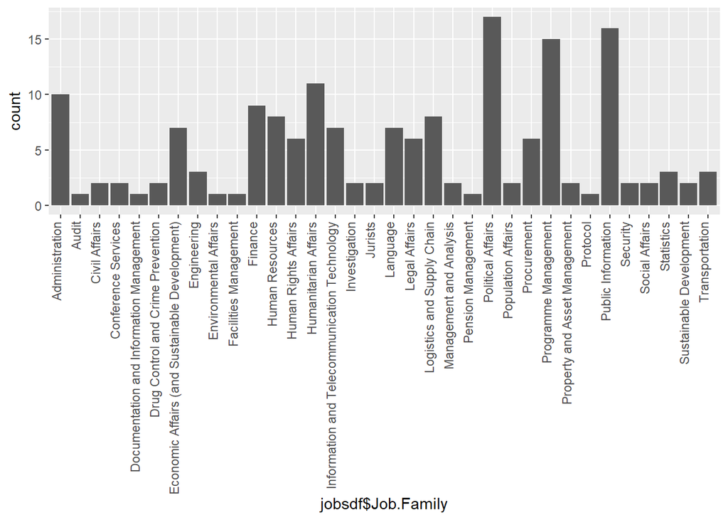

So there is a lot of variety there, which is to be expected. To see better let’s pull up the top 10 in a table:

|  | x | freq |
| --- | --- | --- |
| 23 | Political Affairs | 17 |
| 29 | Public Information | 16 |
| 26 | Programme Management | 15 |
| 14 | Humanitarian Affairs | 11 |
| 1 | Administration | 10 |
| 11 | Finance | 9 |
| 12 | Human Resources | 8 |
| 20 | Logistics and Supply Chain | 8 |
| 7 | Economic Affairs (and Sustainable Development) | 7 |
| 15 | Information and Telecommunication Technology | 7 |

So research in ecology is not in the top 10… Too bad for me! If you’re into Political affairs, Project management or Public information, you’re in luck.

## Minimum number of years of experience for recruitment and quantity of people hired per level

Now is when we find out if we will ever have a shot at working for the UN. I had to look up on the website what the job level codes are, and reported them below so we can make sense of the data:

http://www.unfpa.org/resources/united-nations-staff-categories

Professional (P) and Director (D) staff

- P1 - No work experience required
- P2 - Minimum of 2 years of work experience
- P3 - Minimum of 5 years of work experience
- P4 - Minimum of 7 years of work experience
- P5 - Minimum of 10 years of work experience
- D1 - Minimum of 15 years of work experience
- D2 - More than 15 years of work experience

General Service (G) staff

- G1 - No work experience required
- G2 - Minimum of 2 years of work experience
- G3 - Minimum of 3 years of work experience
- G4 - Minimum of 4 years of work experience
- G5 - Minimum of 5 years of work experience
- G6 - Minimum of 6 years of work experience
- G7 - Minimum of 7 years of work experience

National Professional Officers (NO)

- NOA - No work experience required
- NOB - Minimum of 2 years of work experience
- NOC - Minimum of 5 years of work experience
- NOD - Minimum of 7 years of work experience

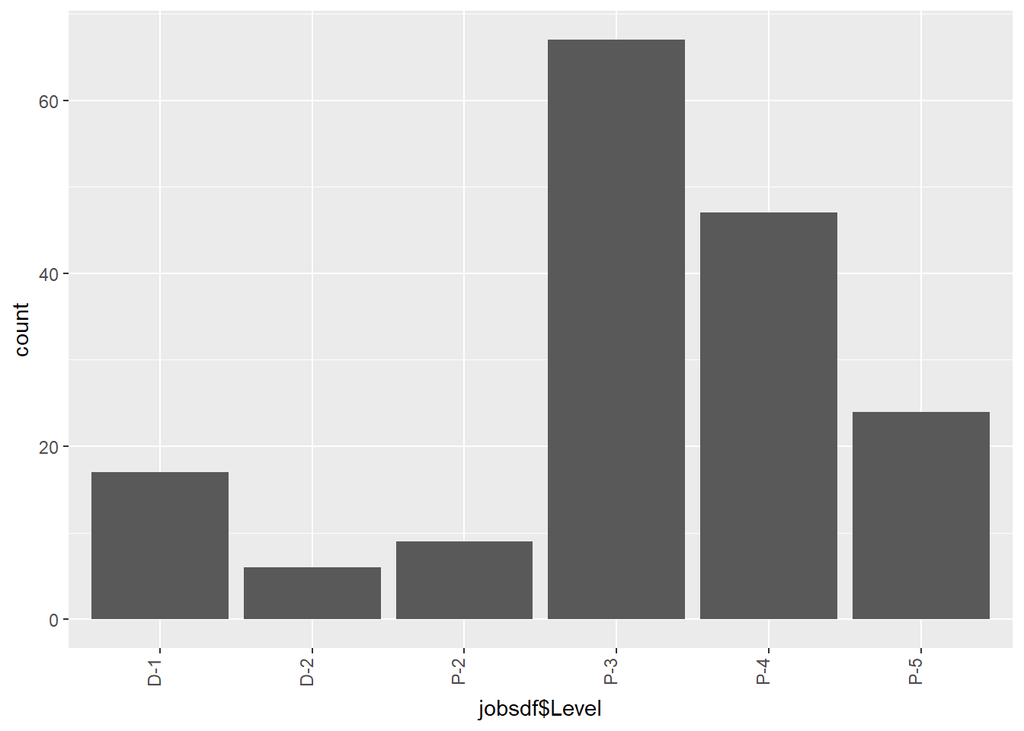

So the most wanted kind of job is P3 - Minimum of 5 years of work experience followed by P4 - Minimum of 7 years of work experience. The number of P2 is very limited as is any position as director. It looks like none of us are going to be recruted right after PhD!

## Countries where most people are recruited

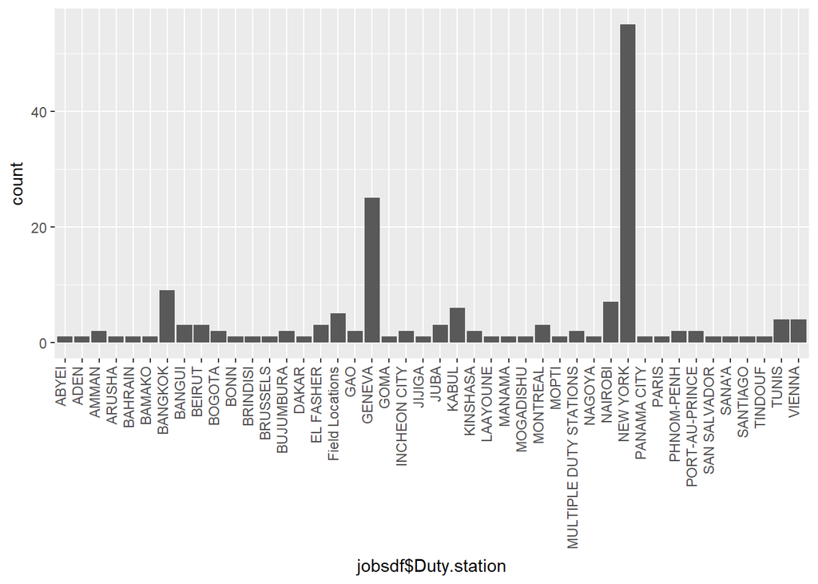

## Department office where most people are recruited

There are difference department offices people can be recruited to which all have very fancy names and sound like they are going to save the world but again, they don’t all recruit the same number of interns so let’s look at the ones that recruit the most:

|  | x | freq |
| --- | --- | --- |
| 5 | Department of Field Support | 11 |
| 11 | Economic and Social Commission for Asia and the Pacific | 11 |
| 20 | Office for the Coordination of Humanitarian Affairs | 13 |
| 31 | United Nations Environment Programme | 14 |

# Internship job offers dataset

This dataset was also downloaded on the same date as the jobs dataset. As before, let’s have a first look at how the dataset is structured:

| Job.Title | Level | Job.ID | Job.Network |
| --- | --- | --- | --- |
| INTERN - ADMINISTRATION[Temporary] | I-1 | 90339 | NA |
| INTERN - PROGRAMME MANAGEMENT[Temporary] | I-1 | 90196 | NA |
| INTERN - ECONOMIC AFFAIRS[Temporary] | I-1 | 82523 | NA |
| INTERN - PUBLIC INFORMATION[Temporary] | I-1 | 91522 | NA |
| INTERN - ENVIRONMENT AFFAIRS (Two Positions)[Temporary] | I-1 | 88958 | NA |
| INTERN - LEGAL AFFAIRS[Temporary] | I-1 | 87466 | Legal |
| LEGAL INTERN - COURT SUPPORT SERVICES SECTION[Temporary][Cancelled] | I-1 | 87393 | Legal |
| INTERN - PUBLIC INFORMATION[Temporary] | I-1 | 87082 | NA |
| INTERN - PUBLIC INFORMATION[Temporary] | I-1 | 87090 | NA |
| INTERN - MINE ACTION[Temporary] | I-1 | 86497 | NA |

It has mostly the same columns as the jobs dataset, so we can use the same code as before to explore it. It has one difference: the job level requirement is always the same, I1, which means there is no difference in requirements of experience unlike the jobs dataset.

## Department offices where most interns are sent

There are a total of 182 different internship offers in our dataset. We want to look closer at department offices: there are 29 different ones. Let’s pull up the department offices that have more than 10 interns sent in our dataset:

|  | x | freq |
| --- | --- | --- |
| 6 | Economic and Social Commission for Asia and the Pacific | 37 |
| 18 | Office of the High Commissioner for Human Rights | 18 |
| 21 | United Nations Environment Programme | 16 |
| 3 | Department of Management | 15 |
| 8 | Economic Commission for Latin America and the Caribbean | 11 |
| 14 | Office of Central Support Services | 11 |

The department that has significantly more intern jobs in our dataset is the Economic and Social Commission for Asia and the Pacific. In the list with more than 10 jobs there is also the Office of the High Commissioner for Human Rights. I was also happy to see the United Nations Environment Programme was also high up in the list.

## Cities that recruit the most interns

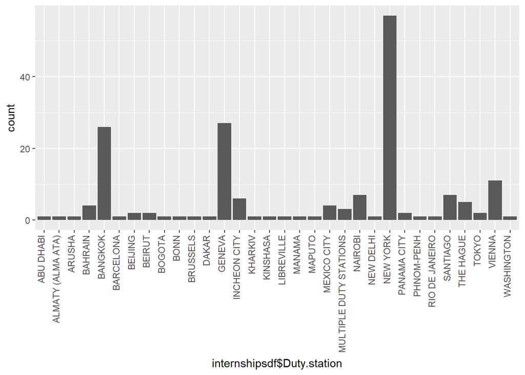

That’s all for now, I’m open to other ideas or representations to code if you have any, and if you’re interested in the code it is down below. This report was generated with Rmarkdown and compiled to html. See you soon,

Adeline

```r
library(xlsx)
library(ggplot2)
library(plyr)
library(knitr)
library(sqldf)
jobsdf <- read.xlsx("UNO_jobs.xlsx", sheetName = "Feuil1")
kable(jobsdf[1:10,1:4])
ggplot(jobsdf, aes(x = jobsdf$Job.Family)) + geom_bar() + theme(axis.text.x  = element_text(angle=90, vjust=0, hjust = 1))
tbl_jobs <- count(jobsdf$Job.Family) # from plyr library
most_wanted_jobs <- tbl_jobs[order(-tbl_jobs$freq),]
kable(most_wanted_jobs[1:10,])
ggplot(jobsdf, aes(x = jobsdf$Level)) + geom_bar() + theme(axis.text.x  = element_text(angle=90, vjust=0, hjust = 1))
ggplot(jobsdf, aes(x = jobsdf$Duty.station)) + geom_bar() + theme(axis.text.x  = element_text(angle=90, vjust=0, hjust = 1))
tbl <- count(jobsdf$Department.Office)
kable(tbl[tbl$freq > 10,])
internshipsdf <- read.xlsx("UNO_jobs_internships.xlsx", sheetName = "Feuil1")
kable(internshipsdf[1:10,1:4])
tbl <- count(internshipsdf$Department.Office)
tbl <- tbl[order(-tbl$freq),]
kable(tbl[tbl$freq > 10,])
ggplot(internshipsdf, aes(x = internshipsdf$Duty.station)) + geom_bar() + theme(axis.text.x  = element_text(angle=90, vjust=0, hjust = 1))
```